# Short software tutorial on `nonprobsvy` package – replicating results from the Kim et al. (2021)

Author

Maciej Beręsewicz

# 1 Basic information

## 1.1 Theory

This notebook is desinged to replicate results from the paper

```
Kim, J. K., Park, S., Chen, Y., & Wu, C. (2021). Combining
non-probability and probability survey samples through mass
imputation. Journal of the Royal Statistical Society Series A:
Statistics in Society, 184(3), 941-963.
```

We generate the data using the following recipe from section 6 of this paper:

The simulation is based on the following assumptions:

- population size $N=100,000$,
- probability sample $A$ of $500$ size,
- non-probability sample $B$ of size $500$ and $1000$,
- $x_{i} \sim N(2,1)$ and $e_{i} \sim (0,1)$,
- the study variable $y_{i}$ is constructed differently for each model:
  - Model I – $y_{i}=1+2 x_{i}+e_{i}$ ($R^2=0.8$),
  - Model II – $y_{i}=3+x_{i}+2e_{i}$ ($R^2=0.2$),
  - Model III – $y_{i}=2.5 + 0.5x_{i}^2+e_{i}$,
- SRS to obtain $A$ from each of three populations,
- Sample $B$ is obtained by SRS within two strata:
  - Strata 1: $x_i <= 2$ with size $n_1=0.7n_b$,
  - Strata 2: $x_i > 2$ with size $n_2 = 0.3n_b$
- Using the two samples $A$ and $B$, for estimators of $\theta_{N}=N^{-1} \sum_{i=1}^{N} y_{i}$ are computed:
  - The sample mean from sample $A$ (denoted as `prob`) : $\widehat{\theta}_{A}=n_{A}^{-1} \sum_{i \in A} y_{i}$,
  - The naive estimator (sample mean) from sample (denoted as `naive`) $B: \widehat{\theta}_{B}=n_{B}^{-1} \sum_{i \in B} y_{i}$.
  - The mass imputation estimator from sample $A$ (denoted as `mi`) given in Equation (6) using $\widehat{y}_{i}=\widehat{\beta}_{0}+\widehat{\beta}_{1} x_{i}$ where $(\widehat{\beta}_{0}, \widehat{\boldsymbol{\beta}}_{1})$ are the estimated regression coefficients obtained from sample $B$.
  - The IPW estimator proposed by Chen, Li, and Wu (2020): $\widehat{\theta}_{I P W}=N^{-1} \sum_{i \in B} \widehat{\pi}_{i}^{-1} y_{i}$ (denoted as `ipw`), where the propensity scores, $\pi_{i}=\pi(\mathbf{x}_{i} ; \boldsymbol{\phi})=\left\{1+\exp (-\phi_{0}-\phi_{1} x_{i})\right\}^{-1}$ with $\mathbf{x}_{i}=(1, x_{i})^{\prime}$ and $\boldsymbol{\phi}=(\phi_{0}, \phi_{1})^{\prime}$, are estimated by using $\widehat{\boldsymbol{\phi}}$ which solves the following score equations:
    $$U(\boldsymbol{\phi})=\sum_{i \in B} \mathbf{x}_{i}-\sum_{i \in A} w_{i} \pi(\mathbf{x}_{i} ; \boldsymbol{\phi}) \mathbf{x}_{i}=\mathbf{0}$$

# 2 Replication

Load required packages

```r
library(nonprobsvy)
library(data.table)
library(ggplot2)
packageVersion("nonprobsvy")
```

```
[1] '0.1.1.9001'
```

## 2.1 Single run

Here’s an example of a single run

```r
set.seed(123123123)
N <- 100000
n_a <- 500
n_b <- 1000
n_b1 <- 0.7*n_b
n_b2 <- 0.3*n_b
x <- rnorm(N, 2, 1)
e <- rnorm(N)
y1 <- 1 + 2*x + e
y2 <- 3 + x + 2*e
y3 <- 2.5 + 0.5*x^2 + e
strata <- x <= 2
pop <- data.frame(x, y1, y2, y3, strata)
sample_a <- pop[sample(1:N, n_a),]
sample_a$w_a <- N/n_a
svy_a <- svydesign(ids= ~1, weights = ~ w_a, data = sample_a)
pop1 <- subset(pop, strata == TRUE)
pop2 <- subset(pop, strata == FALSE)
sample_b <- rbind(pop1[sample(1:nrow(pop1), n_b1), ],
                  pop2[sample(1:nrow(pop2), n_b2), ])
## mass imputation
res_y <- nonprob(outcome = y1 + y2 + y3 ~ x, data = sample_b, svydesign = svy_a)


data.frame(est = c("mi_y1","mi_y2", "mi_y3"),
           true = colMeans(sample_a[, c("y1", "y2", "y3")]),
           naive_B = colMeans(sample_b[, c("y1", "y2", "y3")]),
           mi = res_y$output$mean)
```

|  | est | true | naive_B | mi |
| --- | --- | --- | --- | --- |
| y1 | mi_y1 | 4.985035 | 4.362648 | 5.051320 |
| y2 | mi_y2 | 4.977527 | 4.737475 | 5.110097 |
| y3 | mi_y3 | 4.984425 | 4.358765 | 4.984990 |

```r
res_y
```

```
A nonprob object
 - estimator type: mass imputation
 - method: glm (gaussian)
 - auxiliary variables source: survey
 - vars selection: false
 - variance estimator: analytic
 - population size fixed: false
 - naive (uncorrected) estimators:
   - variable y1: 4.3626
   - variable y2: 4.7375
   - variable y3: 4.3588
 - selected estimators:
   - variable y1: 5.0513 (se=0.0984, ci=(4.8585, 5.2441))
   - variable y2: 5.1101 (se=0.0857, ci=(4.9422, 5.2780))
   - variable y3: 4.9850 (se=0.0946, ci=(4.7996, 5.1704))
```

## 2.2 Simulation

Code for simulation is available here where:

- `naive` – based on non-probability sample
- `prob` – based on probability sample
- `mi` – based on Mass Imputation (GLM linear regression)
- `ipw` – based on IPW estimator

```r
results <- readRDS("../results/kim2021-replicates.rds")
results[, est := factor(est, c("prob","naive",  "mi", "ipw"))]
```

Coverage of confidence intervals using analytical variance

```r
results[!is.na(lower_bound), .(m = mean(lower_bound < true & upper_bound > true)), keyby=.(y, est)][est == "mi"]
```

| y | est | m |
| --- | --- | --- |
| 1 | mi | 0.944 |
| 2 | mi | 0.958 |
| 3 | mi | 0.903 |

Table with main results

```r
results[, .(bias = mean(mean) - mean(true), var = var(mean)*1000,
                  mse = (mean(mean) - mean(true))^2 + var(mean),
                  rmse = sqrt((mean(mean) - mean(true))^2 + var(mean))),
              keyby=.(y, est)][, ReMSE:=mse/mse[est=="prob"]*100][]
```

| y | est | bias | var | mse | rmse | ReMSE |
| --- | --- | --- | --- | --- | --- | --- |
| 1 | prob | 0.0034728 | 10.607029 | 0.0106191 | 0.1030490 | 100.00000 |
| 1 | naive | -0.6275248 | 2.334274 | 0.3961217 | 0.6293820 | 3998.61850 |
| 1 | mi | 0.0027064 | 9.380883 | 0.0093882 | 0.0968928 | 77.83251 |
| 1 | ipw | -0.0429196 | 13.582607 | 0.0154247 | 0.1241962 | 145.25447 |
| 2 | prob | 0.0050075 | 9.881389 | 0.0099065 | 0.0995312 | 100.00000 |
| 2 | naive | -0.3103812 | 4.162636 | 0.1004991 | 0.3170159 | 833.18329 |
| 2 | mi | 0.0034746 | 6.077056 | 0.0060891 | 0.0780329 | 57.34135 |
| 2 | ipw | -0.0275273 | 7.866437 | 0.0086242 | 0.0928665 | 87.05616 |
| 3 | prob | 0.0031174 | 12.052347 | 0.0120621 | 0.1098274 | 100.00000 |
| 3 | naive | -0.6274729 | 2.240911 | 0.3959631 | 0.6292560 | 3728.78620 |
| 3 | mi | -0.0536802 | 8.686117 | 0.0115677 | 0.1075531 | 116.76899 |
| 3 | ipw | -0.0443559 | 18.560292 | 0.0205277 | 0.1432750 | 170.18424 |

We can compare the results with table 3 from Kim et al. (2021)

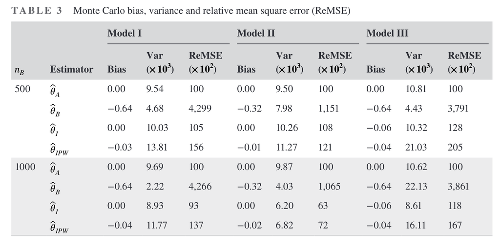

Plot with results

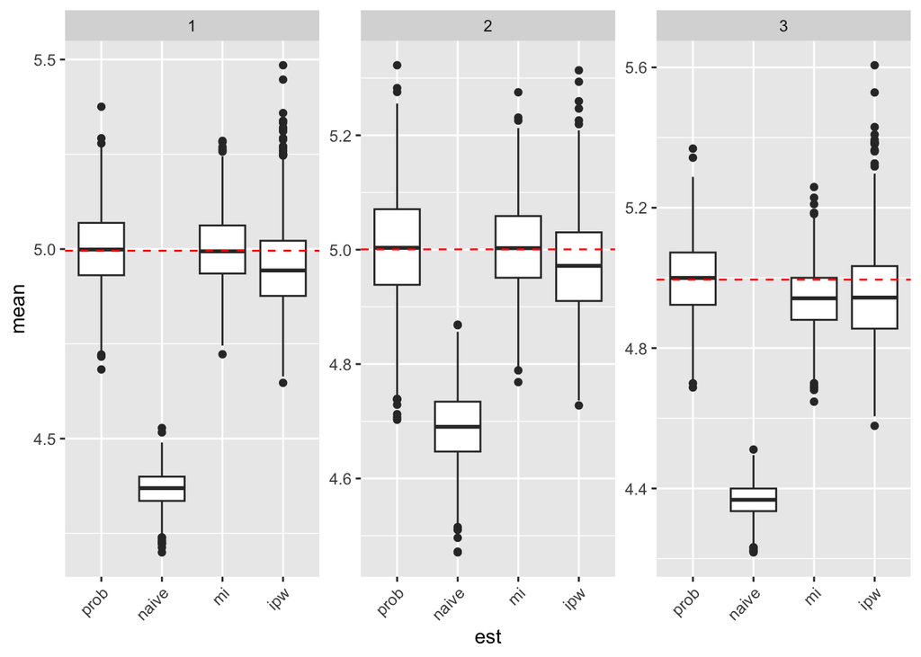

```r
ggplot(data = results, aes(x = est, y = mean)) +
  geom_boxplot(position = "dodge") +
  geom_hline(aes(yintercept = true), color = "red", linetype = "dashed") +
  facet_wrap(~y, ncol = 3, scales = "free_y") +
  theme(axis.text.x=element_text(angle = 45, vjust = 1, hjust = 1))
```

## References

Chen, Yilin, Pengfei Li, and Changbao Wu. 2020. “Doubly Robust Inference With Nonprobability Survey Samples.” *Journal of the American Statistical Association* 115 (532): 2011–21. https://doi.org/10.1080/01621459.2019.1677241.

Kim, Jae Kwang, Seho Park, Yilin Chen, and Changbao Wu. 2021. “Combining Non-Probability and Probability Survey Samples Through Mass Imputation.” *Journal of the Royal Statistical Society Series A: Statistics in Society* 184 (3): 941–63. https://doi.org/10.1111/rssa.12696.